# Practical Machine Leaning Project

Carlo G. Inovero

December 2, 2018

# Project Description

Using devices such as Jawbone Up, Nike FuelBand, and Fitbit it is now possible to collect a large amount of data about personal activity relatively inexpensively. These type of devices are part of the quantified self movement - a group of enthusiasts who take measurements about themselves regularly to improve their health, to find patterns in their behavior, or because they are tech geeks. One thing that people regularly do is quantify how much of a particular activity they do, but they rarely quantify how well they do it. In this project, your goal will be to use data from accelerometers on the belt, forearm, arm, and dumbell of 6 participants. They were asked to perform barbell lifts correctly and incorrectly in 5 different ways. More information is available from the website here: http://groupware.les.inf.puc-rio.br/har (see the section on the Weight Lifting Exercise Dataset).

## Project Objective

This report aims predict the class of exercise an individual perfomed while wearing fitness trackers by using machine learning algorithms. I will partition and prescreen some of the data to afford me higher accuracy.

## Loading Package

```r
library(caret)
```

```r
library(rpart)
library(rpart.plot)
library(RColorBrewer)
library(rattle) ## Rattle: A free graphical interface for data mining with R.
library(randomForest)
library(knitr)
```

## Loading Files

```r
knitr::opts_chunk$set(echo = TRUE)
pmlTrainData <- read.csv ("pml-training.csv", header = TRUE)
pmlTestData <- read.csv("pml-testing.csv", header = TRUE)
```

## Cleaning Data

#### Getting the indexes of the columns having at least 90% of NA or blank values.

The training data set is made of 19622 observations on 160 columns. We can notice that many columns have NA values or blank values on almost every observation. So we will remove them, because they will not produce any information. The first seven columns give information about the people who did the test, and also timestamps. We will not take them in our model.

After cleaning the data, the new data set should have 53 columns.

```r
knitr::opts_chunk$set(echo = TRUE)
trainColRemove <- which(colSums(is.na(pmlTrainData) |pmlTrainData=="")>0.9*dim(pmlTrainData)[1])
myTrainDataClean <- pmlTrainData[,-trainColRemove]
myTrainDataClean <- myTrainDataClean[,-c(1:7)]
dim(myTrainDataClean)
```

```
## [1] 19622    53
```

```r
TestColToRemove <- which(colSums(is.na(pmlTestData) |pmlTestData=="")>0.9*dim(pmlTestData)[1])
myTestDataClean <- pmlTestData[,-TestColToRemove]
myTestDataClean <- myTestDataClean[,-1]
dim(myTestDataClean)
```

```
## [1] 20 59
```

## Partitioning of Data

```r
set.seed(12345)
inTrainData <- createDataPartition (y = myTrainDataClean$classe, p=0.7, list=FALSE)
myTrainData  <- myTrainDataClean[inTrainData, ];
myTestData  <- myTrainDataClean[-inTrainData, ];
dim(myTrainData);
```

```
## [1] 13737    53
```

```r
dim(myTestData);
```

```
## [1] 5885   53
```

## Remove variables with nearly zero variance

```r
knitr::opts_chunk$set(echo = TRUE)
nvrTrainData <- nearZeroVar(myTrainData, saveMetrics=TRUE)
myTrainData <- myTrainData[,nvrTrainData$nzv==FALSE]

nvrTestData <- nearZeroVar(myTestData,saveMetrics=TRUE)
myTestData <- myTestData[,nvrTestData$nzv ==FALSE]


myTrainData <- myTrainData[c(-1)]
dim(myTrainData)
```

```
## [1] 13737    52
```

```r
cleanTrainData <- myTrainData
for(i in 1:length (myTrainData)) {
        if( sum( is.na (myTrainData [, i] ) ) / nrow (myTrainData) >= 0.7) {
            for(j in 1:length(cleanTrainData)) {
                  if( length( grep (names (myTrainData[i]), names(cleanTrainData)[j]) ) == 1)  {
                        cleanTrainData  <- cleanTrainData [ , -j]
                        }
             }
        }
}

myTrainData <- cleanTrainData
rm(cleanTrainData)


clean1 <- colnames(myTrainData)
clean2 <- colnames(myTrainData[, -58])  # remove the classe column
myTestData <- myTestData[clean1]        # allow only variables in myTesting that are also in mytraindata
myTestData2 <- myTestData [clean2]      # allow only variables in testing that are also in mytraindata

dim(myTestData2)
```

```
## [1] 5885   52
```

```r
for (i in 1:length(myTestData2) ) {
  for(j in 1:length(myTrainData)) {
    if( length( grep(names(myTrainData[i]), names(myTestData2)[j]) ) == 1)  {
      class(myTestData2[j]) <- class(myTrainData[i])
    }
  }
}
```

#### To get the same class between testing and myTraining

```r
myTestData2 <- rbind(myTrainData[2, -58] , myTestData2)
myTestData2 <- myTestData2[-1,]
```

## Prediction with Decision tree

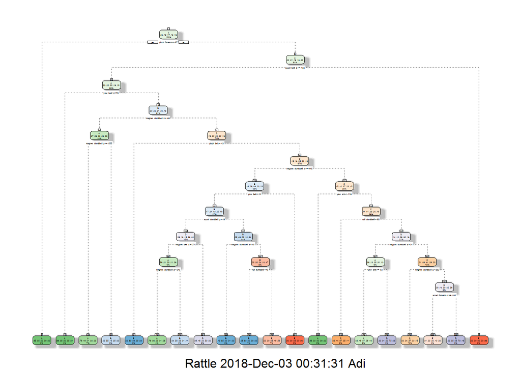

```r
knitr::opts_chunk$set(echo = TRUE)
set.seed(12345)
ModelFit1 <- rpart(classe ~ ., data=myTrainData, method="class")
fancyRpartPlot(ModelFit1)
```

```r
PredictModel1 <- predict(ModelFit1 , myTestData2, type = "class")
ClassTree <- confusionMatrix(PredictModel1, myTestData2$classe)
ClassTree
```

```
## Confusion Matrix and Statistics
##
##           Reference
## Prediction    A    B    C    D    E
##          A 1509  219   54   71   98
##          B   31  553   53   62   40
##          C   34   98  687  170  160
##          D   72  116  122  576   46
##          E   28  153  110   85  738
##
## Overall Statistics
##
##                Accuracy : 0.6904
##                  95% CI : (0.6784, 0.7022)
##     No Information Rate : 0.2845
##     P-Value [Acc > NIR] : < 2.2e-16
##
##                   Kappa : 0.6064
##  Mcnemar's Test P-Value : < 2.2e-16
##
## Statistics by Class:
##
##                      Class: A Class: B Class: C Class: D Class: E
## Sensitivity            0.9014  0.48551   0.6696  0.59751   0.6821
## Specificity            0.8950  0.96081   0.9049  0.92766   0.9217
## Pos Pred Value         0.7734  0.74831   0.5979  0.61803   0.6625
## Neg Pred Value         0.9581  0.88613   0.9284  0.92166   0.9279
## Prevalence             0.2845  0.19354   0.1743  0.16381   0.1839
## Detection Rate         0.2564  0.09397   0.1167  0.09788   0.1254
## Detection Prevalence   0.3315  0.12557   0.1952  0.15837   0.1893
## Balanced Accuracy      0.8982  0.72316   0.7873  0.76258   0.8019
```

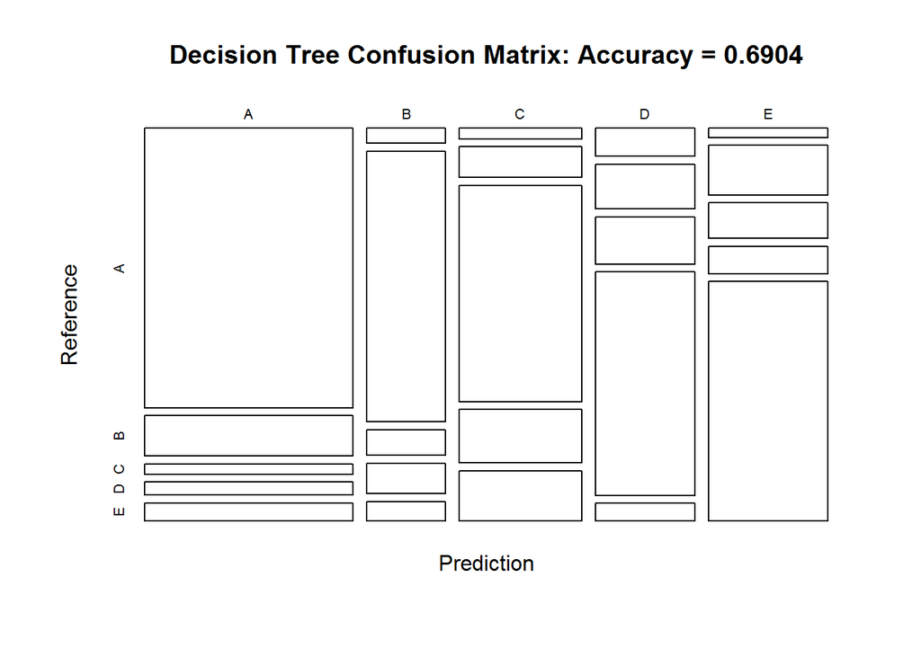

```r
plot(ClassTree$table, col = ClassTree$byClass,
     main = paste("Decision Tree Confusion Matrix: Accuracy =", round(ClassTree$overall['Accuracy'], 4)))
```

## Prediction with Random Forest

```r
knitr::opts_chunk$set(echo = TRUE)
set.seed(12345)
ModelFit2 <- randomForest(classe ~ ., data=myTrainData)
PredictionModel2 <- predict(ModelFit2, myTestData2, type = "class")
RandomForestModel <- confusionMatrix(PredictionModel2, myTestData2$classe)
RandomForestModel
```

```
## Confusion Matrix and Statistics
##
##           Reference
## Prediction    A    B    C    D    E
##          A 1673    9    0    0    0
##          B    1 1126   11    0    0
##          C    0    4 1013   13    0
##          D    0    0    2  951    4
##          E    0    0    0    0 1078
##
## Overall Statistics
##
##                Accuracy : 0.9925
##                  95% CI : (0.99, 0.9946)
##     No Information Rate : 0.2845
##     P-Value [Acc > NIR] : < 2.2e-16
##
##                   Kappa : 0.9905
##  Mcnemar's Test P-Value : NA
##
## Statistics by Class:
##
##                      Class: A Class: B Class: C Class: D Class: E
## Sensitivity            0.9994   0.9886   0.9873   0.9865   0.9963
## Specificity            0.9979   0.9975   0.9965   0.9988   1.0000
## Pos Pred Value         0.9946   0.9895   0.9835   0.9937   1.0000
## Neg Pred Value         0.9998   0.9973   0.9973   0.9974   0.9992
## Prevalence             0.2845   0.1935   0.1743   0.1638   0.1839
## Detection Rate         0.2843   0.1913   0.1721   0.1616   0.1832
## Detection Prevalence   0.2858   0.1934   0.1750   0.1626   0.1832
## Balanced Accuracy      0.9986   0.9930   0.9919   0.9926   0.9982
```

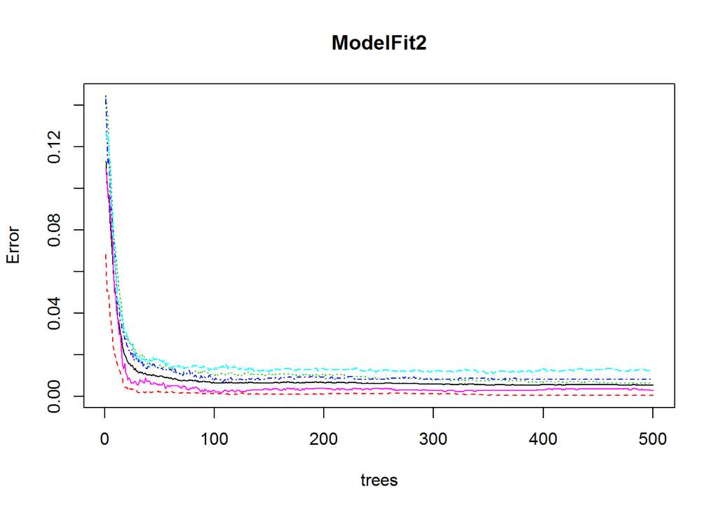

```r
plot(ModelFit2)
```

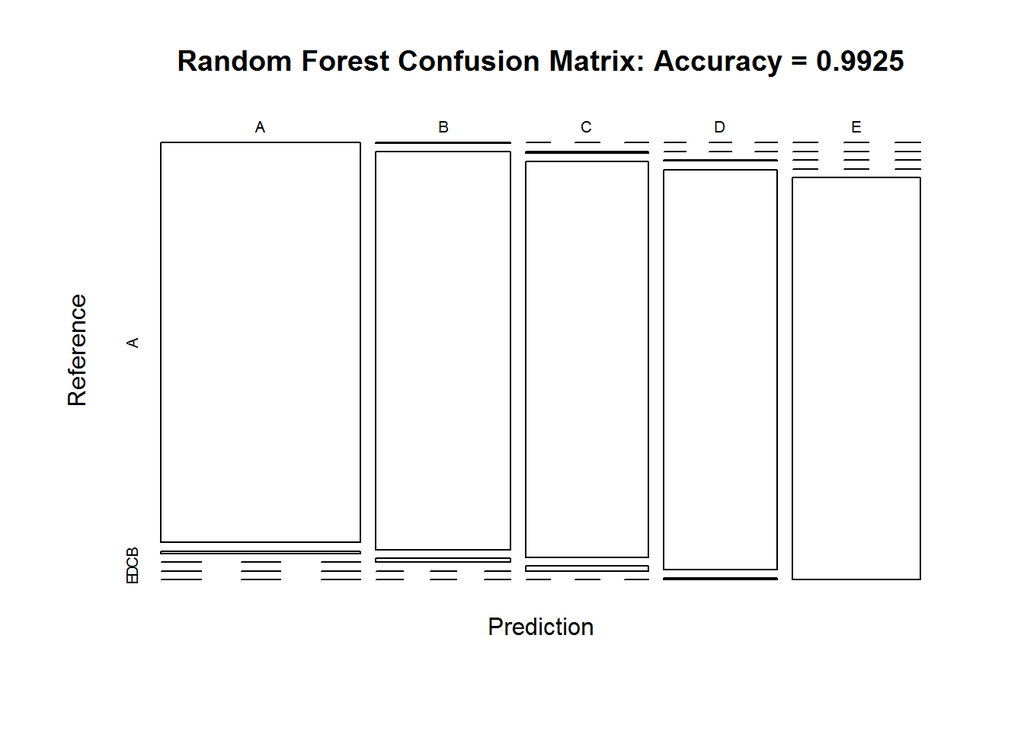

```r
plot(RandomForestModel$table, col = ClassTree$byClass,
     main = paste("Random Forest Confusion Matrix: Accuracy =", round(RandomForestModel$overall['Accuracy'], 4)))
```

## General Boost Regression

```r
knitr::opts_chunk$set(echo = TRUE)
set.seed(12345)
FitControl <- trainControl(method = "repeatedcv",
                           number = 5,
                           repeats = 1)

GRBFit <- train(classe ~ ., data=myTrainData, method = "gbm",
                 trControl = FitControl,
                 verbose = FALSE)


GBRModel <- GRBFit$finalModel

GBRPredictTest <- predict(GRBFit, newdata=myTestData2)
GBRAccuracy <- confusionMatrix(GBRPredictTest, myTestData2$classe)
GBRAccuracy
```

```
## Confusion Matrix and Statistics
##
##           Reference
## Prediction    A    B    C    D    E
##          A 1648   41    0    2    1
##          B   20 1059   37    1   12
##          C    3   34  977   40    7
##          D    2    2   12  909   21
##          E    1    3    0   12 1041
##
## Overall Statistics
##
##                Accuracy : 0.9573
##                  95% CI : (0.9519, 0.9624)
##     No Information Rate : 0.2845
##     P-Value [Acc > NIR] : < 2.2e-16
##
##                   Kappa : 0.946
##  Mcnemar's Test P-Value : 1.317e-05
##
## Statistics by Class:
##
##                      Class: A Class: B Class: C Class: D Class: E
## Sensitivity            0.9845   0.9298   0.9522   0.9429   0.9621
## Specificity            0.9896   0.9853   0.9827   0.9925   0.9967
## Pos Pred Value         0.9740   0.9380   0.9208   0.9609   0.9849
## Neg Pred Value         0.9938   0.9832   0.9898   0.9889   0.9915
## Prevalence             0.2845   0.1935   0.1743   0.1638   0.1839
## Detection Rate         0.2800   0.1799   0.1660   0.1545   0.1769
## Detection Prevalence   0.2875   0.1918   0.1803   0.1607   0.1796
## Balanced Accuracy      0.9870   0.9575   0.9675   0.9677   0.9794
```

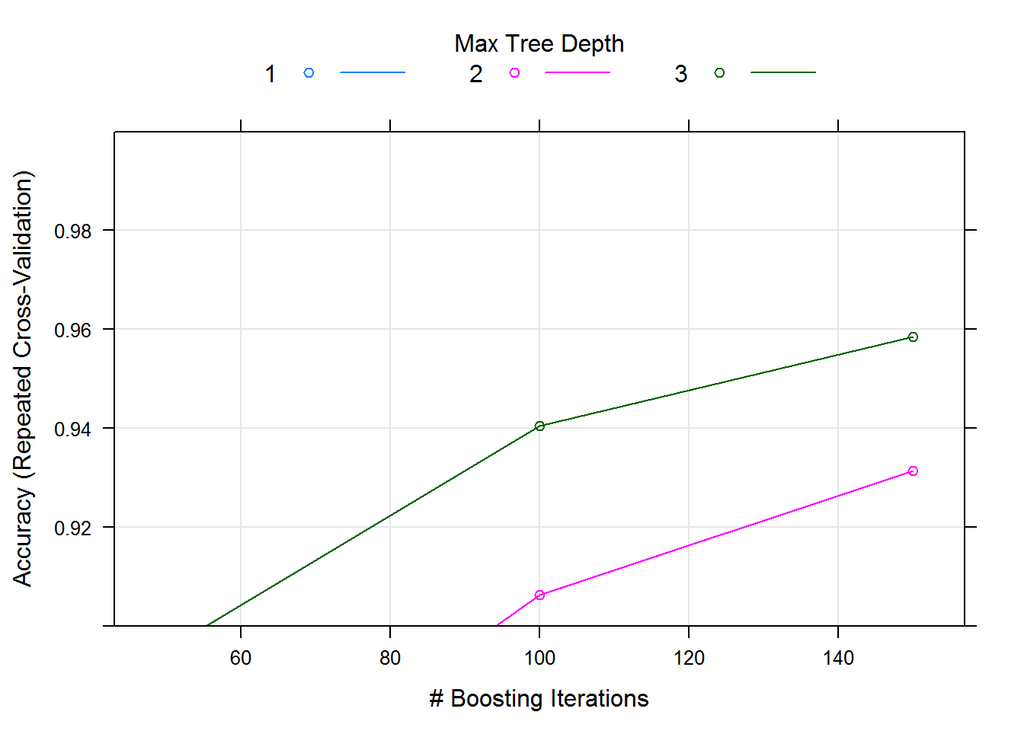

```r
plot(GRBFit , ylim=c(0.9, 1))
```